# HW2

Zachary Gonzalez

1/27/2022

Install bioconductor

```r
if (!require("BiocManager", quietly = TRUE))
    install.packages("BiocManager")
BiocManager::install(version = "3.12")
```

Install multtest package

```r
BiocManager::install(c("multtest"))
```

Import Data set

```r
library(multtest)
data(golub)
```

```r
gol.fac <- factor(golub.cl, levels=0:1, labels = c("ALL", "AML"))
gol.fac
```

```
##  [1] ALL ALL ALL ALL ALL ALL ALL ALL ALL ALL ALL ALL ALL ALL ALL ALL ALL ALL ALL
## [20] ALL ALL ALL ALL ALL ALL ALL ALL AML AML AML AML AML AML AML AML AML AML AML
## Levels: ALL AML
```

Question 1 part a - compute mean expression of the values among ALL patients

```r
meanAll <- apply(golub[,gol.fac=="ALL"], 1, mean)
```

Question 1 part b - compute the mean expression of the values among AML patients

```r
meanAML <- apply(golub[,gol.fac=="AML"], 1, mean)
```

Question 1 part c - output top three mean values for ALL data

```r
orderAll<-order(meanAll, decreasing = TRUE)
print(golub.gnames[orderAll[1:3],2])
```

```
## [1] "GB DEF = Chromosome 1q subtelomeric sequence D1S553"
## [2] "37 kD laminin receptor precursor/p40 ribosome associated protein gene"
## [3] "RPS14 gene (ribosomal protein S14) extracted from Human ribosomal protein S14 gene"
```

Question 1 part d - output top three mean values for AML data

```r
orderAML<-order(meanAML, decreasing = TRUE)
print(golub.gnames[orderAML[1:3],2])
```

```
## [1] "GB DEF = mRNA fragment for elongation factor TU (N-terminus)"
## [2] "GB DEF = HLA-B null allele mRNA"
## [3] "Globin, Beta"
```

Question 2 part a - save the expression values of the first five genes (of first five rows) for AML patients in a csv file

```r
orderGenesAML<-order(gol.fac=="AML", decreasing = TRUE)
write.csv(golub.gnames[orderGenesAML[1:5],2], "AML5.csv")
```

Question 2 part b - save the expression values of the first five genes (of first five rows) for ALL patients in a text file

```r
orderGenesALL<-order(gol.fac=="ALL", decreasing = TRUE)
write.table(golub.gnames[orderGenesALL[1:5],2], "ALL5.txt")
```

Question 2 part c - compute the stdev of the expression values on the first patient of the 100th to 200th genes

```r
sd(golub[100:200,1])
```

```
## [1] 0.9174976
```

Question 2 part d - compute the stdev of the expression values of every gene, across all patients - find the # of genes with stdev greater than 1

```r
sum(apply(golub, 1, sd) > 1)
```

```
## [1] 123
```

Question 2 part e - Create a scatter plot of the 101th gene expressions against the 102th gene expressions, label the x-axis and the y-axis with genes biological names using xlab and ylab

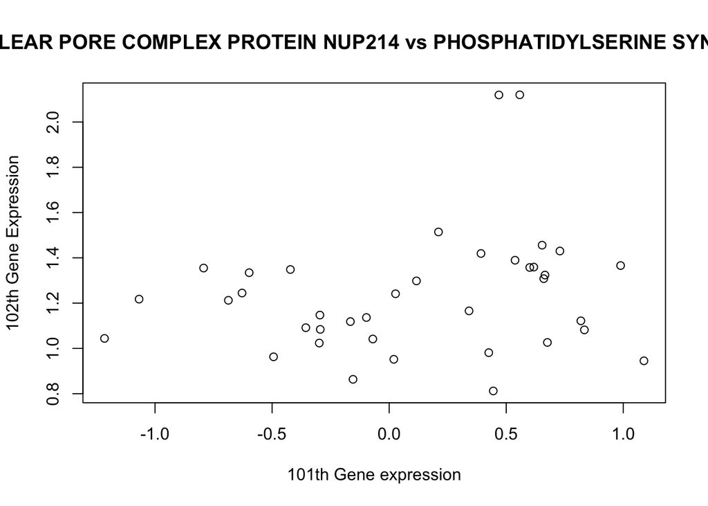

```r
plot(golub[101,], golub[102,], xlab = "101th Gene expression", ylab = "102th Gene Expression", main = paste(golub.gnames[101,2], "vs" , golub.gnames[102,2]))
```

Question 3

```r
BiocManager::install("ALL")
library("ALL")
data(ALL)
```

Question 3 part a - Produce a histogram of gene expressions in the matrix

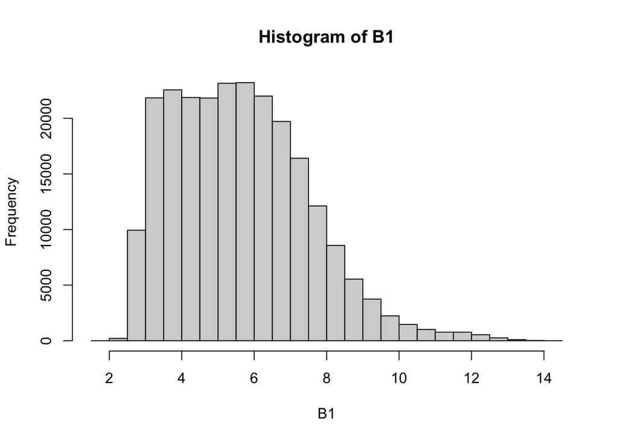

```r
B1 = exprs(ALL[,ALL$BT=="B1"])
hist(B1)
```

Question 3 part c - give the gene identifiers of the three genes with the largest mean value

```r
names(sort(apply(exprs(ALL[,ALL$BT=="B1"]), 1, mean), decreasing = TRUE)[1:3])
```

```
## [1] "AFFX-hum_alu_at" "31962_at"        "31957_r_at"
```

Question 4 part a

Trees object is of type data frame

```r
# find the type of the trees data object
data(trees)
class(trees)
```

```
## [1] "data.frame"
```

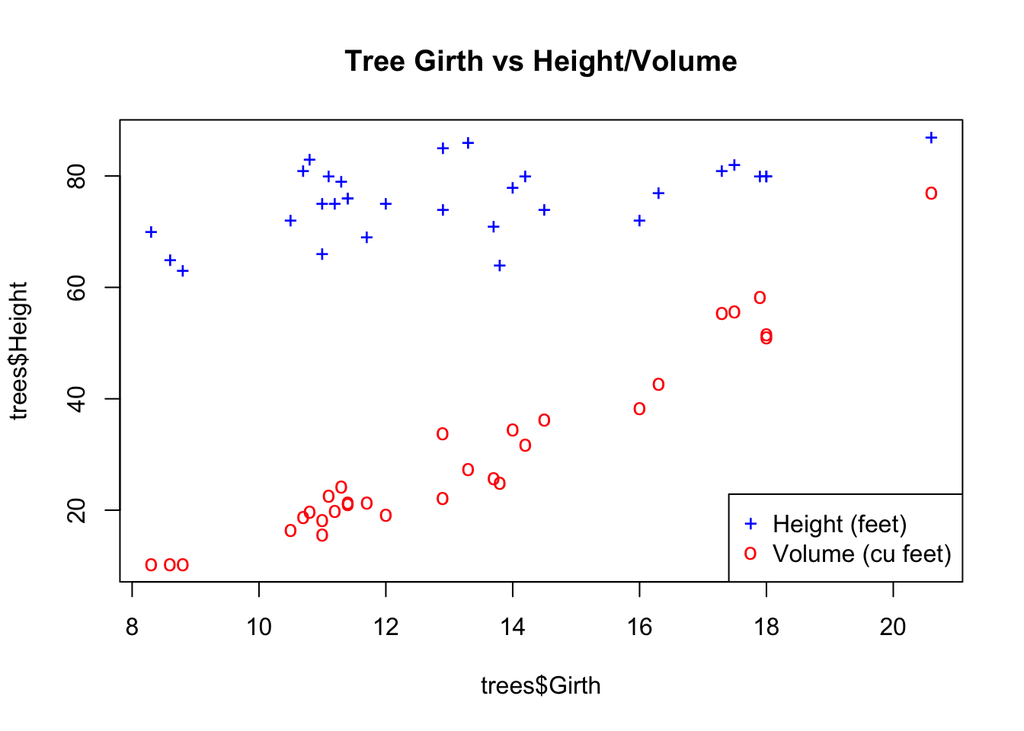

```r
plot(trees$Girth, trees$Height, pch = "+", col = "blue",
     ylim = c(min(c(trees$Height, trees$Volume)), max(c(trees$Height, trees$Volume))),
     main = "Tree Girth vs Height/Volume")
points(trees$Girth, trees$Volume, pch = "o", col = "red")
legend("bottomright",
       legend = c("Height (feet)", "Volume (cu feet)"),
       pch = c("+", "o"),
       col = c("blue", "red"))
```